# Introduction to **agricolae**

Felipe de Mendiburu<sup>1</sup>, Muhammad Yaseen<sup>2</sup>

2020-05-02

1. Professor of the Academic Department of Statistics and Informatics of the Faculty of Economics and Planning.National University Agraria La Molina-PERU.
2. Department of Mathematics and Statistics, University of Agriculture Faisalabad, Pakistan.

# 1 Preface

The following document was developed to facilitate the use of **agricolae** package in **R**, it is understood that the user knows the statistical methodology for the design and analysis of experiments and through the use of the functions programmed in **agricolae** facilitate the generation of the field book experimental design and their analysis. The first part document describes the use of `graph.freq` role is complementary to the `hist` function of **R** functions to facilitate the collection of statistics and frequency table, statistics or grouped data histogram based training grouped data and graphics as frequency polygon or ogive; second part is the development of experimental plans and numbering of the units as used in an agricultural experiment; a third part corresponding to the comparative tests and finally provides **agricolae** miscellaneous additional functions applied in agricultural research and stability functions, soil consistency, late blight simulation and others.

# 2 Introduction

The package **agricolae** offers a broad functionality in the design of experiments, especially for experiments in agriculture and improvements of plants, which can also be used for other purposes. It contains the following designs: lattice, alpha, cyclic, balanced incomplete block designs, complete randomized blocks, Latin, Graeco-Latin, augmented block designs, split plot and strip plot. It also has several procedures of experimental data analysis, such as the comparisons of treatments of Waller-Duncan, Bonferroni, Duncan, Student-Newman-Keuls, Scheffe, Ryan, Einot and Gabriel and Welsch multiple range test or the classic LSD and Tukey; and non-parametric comparisons, such as Kruskal-Wallis, Friedman, Durbin, Median and Waerden, stability analysis, and other procedures applied in genetics, as well as procedures in biodiversity and descriptive statistics, Mendiburu (2009)

## 2.1 Installation

The main program of **R** should be already installed in the platform of your computer *(Windows, Linux or MAC)*. If it is not installed yet, you can download it from the R project https://www.r-project.org/ of a repository CRAN.

```r
install.packages("agricolae")
```

Once the `agricolae` package is installed, it needs to be made accessible to the current **R** session by the command:

```r
library(agricolae)
```

For online help facilities or the details of a particular command (such as the function `waller.test`) you can type:

```r
help(package="agricolae")
help(waller.test)
```

For a complete functionality, `agricolae` requires other packages

| [`MASS`](https://cran.r-project.org/web/packages/MASS/index.html): | for the generalized inverse used in the function `PBIB.test` |
| --- | --- |
| [`nlme`](https://cran.r-project.org/web/packages/nlme/index.html): | for the methods REML and LM in `PBIB.test` |
| [`klaR`](https://cran.r-project.org/web/packages/klaR/index.html): | for the function `triplot` used in the function `AMMI` |
| [`cluster`](https://cran.r-project.org/web/packages/cluster/index.html): | for the use of the function `consensus` |
| [`AlgDesign`](https://cran.r-project.org/web/packages/AlgDesign/index.html): | for the balanced incomplete block design `design.bib` |

## 2.2 Use in **R**

Since **agricolae** is a package of functions, these are operational when they are called directly from the console of **R** and are integrated to all the base functions of **R**. The following orders are frequent:

```r
detach(package:agricolae) # detach package agricole
library(agricolae) # Load the package to the memory
designs<-apropos("design")
print(designs[substr(designs,1,6)=="design"], row.names=FALSE)
```

```
 [1] "design.ab"      "design.alpha"   "design.bib"     "design.crd"
 [5] "design.cyclic"  "design.dau"     "design.graeco"  "design.lattice"
 [9] "design.lsd"     "design.rcbd"    "design.split"   "design.strip"
[13] "design.youden"
```

```r
For the use of symbols that do not appear in the keyboard in Spanish, such as:

~, [, ], &, ^, |. <, >, {, }, \% or others, use the table ASCII code.
```

```r
library(agricolae) # Load the package to the memory:
```

In order to continue with the command line, do not forget to close the open windows with any R order. For help:

```r
help(graph.freq)
? (graph.freq)
str(normal.freq)
example(join.freq)
```

## 2.3 Data set in **agricolae**

```r
A<-as.data.frame(data(package="agricolae")$results[,3:4])
A[,2]<-paste(substr(A[,2],1,35),"..",sep=".")
head(A)
```

```
           Item Title
1       Chz2006   ...
2           CIC   ...
3          clay   ...
4 ComasOxapampa   ...
5          corn   ...
6        cotton   ...
```

# 3 Descriptive statistics

The package **agricolae** provides some complementary functions to the **R** program, specifically for the management of the histogram and function *hist*.

## 3.1 Histogram

The histogram is constructed with the function *graph.freq* and is associated to other functions: *polygon.freq, table.freq, stat.freq*. See Figures: 3.1, 3.2 and 3.3 for more details.

Example. Data generated in **R** . (students’ weight).

```r
weight<-c( 68, 53, 69.5, 55, 71, 63, 76.5, 65.5, 69, 75, 76, 57, 70.5, 71.5, 56, 81.5,
           69, 59, 67.5, 61, 68, 59.5, 56.5, 73, 61, 72.5, 71.5, 59.5, 74.5, 63)
print(summary(weight))
```

```
   Min. 1st Qu.  Median    Mean 3rd Qu.    Max.
  53.00   59.88   68.00   66.45   71.50   81.50
```

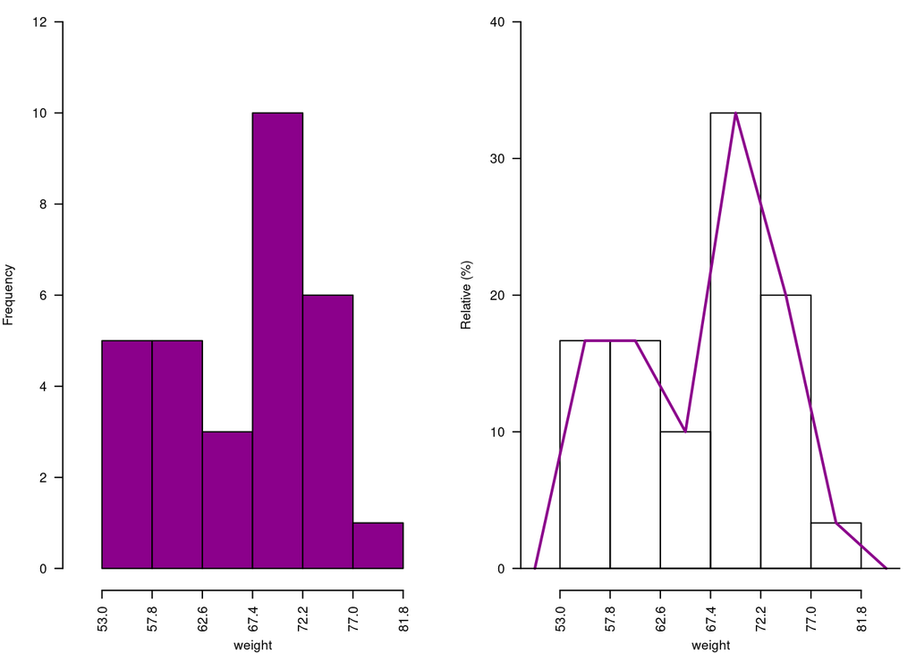

Figure 3.1: Absolute and relative frequency with polygon

```r
oldpar<-par(mfrow=c(1,2),mar=c(4,4,0,1),cex=0.6)
h1<- graph.freq(weight,col=colors()[84],frequency=1,las=2, ylim=c(0,12),ylab="Frequency")
x<-h1$breaks
h2<- plot(h1, frequency =2, axes= FALSE,ylim=c(0,0.4),xlab="weight",ylab="Relative (%)")
polygon.freq(h2, col=colors()[84], lwd=2, frequency =2)
axis(1,x,cex=0.6,las=2)
y<-seq(0,0.4,0.1)
axis(2, y,y*100,cex=0.6,las=1)
```

```r
par(oldpar)
```

## 3.2 Statistics and Frequency tables

Statistics: mean, median, mode and standard deviation of the grouped data.

```r
stat.freq(h1)
```

```
$variance
[1] 51.37655

$mean
[1] 66.6

$median
[1] 68.36

$mode
       [-   -]     mode
[1,] 67.4 72.2 70.45455
```

Frequency tables: Use *table.freq*, *stat.freq* and *summary*

The table.freq is equal to summary()

Limits class: **Lower and Upper**

Class point: **Main**

Frequency: **Frequency**

Percentage frequency: **Percentage**

Cumulative frequency: **CF**

Cumulative percentage frequency: **CPF**

```r
print(summary(h1),row.names=FALSE)
```

```
 Lower Upper Main Frequency Percentage CF   CPF
  53.0  57.8 55.4         5       16.7  5  16.7
  57.8  62.6 60.2         5       16.7 10  33.3
  62.6  67.4 65.0         3       10.0 13  43.3
  67.4  72.2 69.8        10       33.3 23  76.7
  72.2  77.0 74.6         6       20.0 29  96.7
  77.0  81.8 79.4         1        3.3 30 100.0
```

## 3.3 Histogram manipulation functions

You can extract information from a histogram such as class intervals *intervals.freq*, attract new intervals with the *sturges.freq* function or to join classes with *join.freq* function. It is also possible to reproduce the graph with the same creator *graph.freq* or function *plot* and overlay normal function with *normal.freq* be it a histogram in absolute scale, relative or density . The following examples illustrates these properties.

```r
sturges.freq(weight)
```

```
$maximum
[1] 81.5

$minimum
[1] 53

$amplitude
[1] 29

$classes
[1] 6

$interval
[1] 4.8

$breaks
[1] 53.0 57.8 62.6 67.4 72.2 77.0 81.8
```

```r
intervals.freq(h1)
```

```
     lower upper
[1,]  53.0  57.8
[2,]  57.8  62.6
[3,]  62.6  67.4
[4,]  67.4  72.2
[5,]  72.2  77.0
[6,]  77.0  81.8
```

```r
join.freq(h1,1:3) -> h3
print(summary(h3))
```

```
  Lower Upper Main Frequency Percentage CF   CPF
1  53.0  67.4 60.2        13       43.3 13  43.3
2  67.4  72.2 69.8        10       33.3 23  76.7
3  72.2  77.0 74.6         6       20.0 29  96.7
4  77.0  81.8 79.4         1        3.3 30 100.0
```

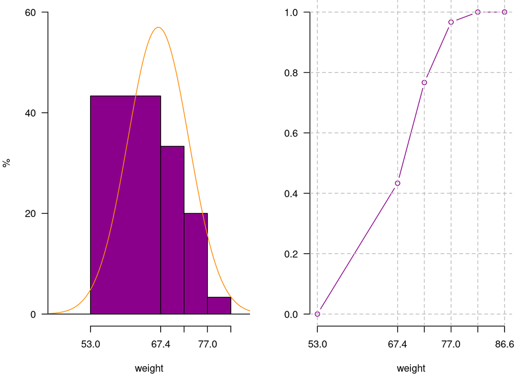

Figure 3.2: Join frequency and relative frequency with normal and Ogive

```
  weight    RCF
1   53.0 0.0000
2   67.4 0.4333
3   72.2 0.7667
4   77.0 0.9667
5   81.8 1.0000
6   86.6 1.0000
```

```r
oldpar<-par(mfrow=c(1,2),mar=c(4,4,0,1),cex=0.8)
plot(h3, frequency=2,col=colors()[84],ylim=c(0,0.6),axes=FALSE,xlab="weight",ylab="%")
y<-seq(0,0.6,0.2)
axis(2,y,y*100,las=2)
axis(1,h3$breaks)
normal.freq(h3,frequency=2,col=colors()[90])
ogive.freq(h3,col=colors()[84],xlab="weight")
```

```r
par(oldpar)
```

## 3.4 hist() and graph.freq() based on grouped data

The *hist* and *graph.freq* have the same characteristics, only f2 allows build histogram from grouped data.

0-10 (3)

10-20 (8)

20-30 (15)

30-40 (18)

40-50 (6)

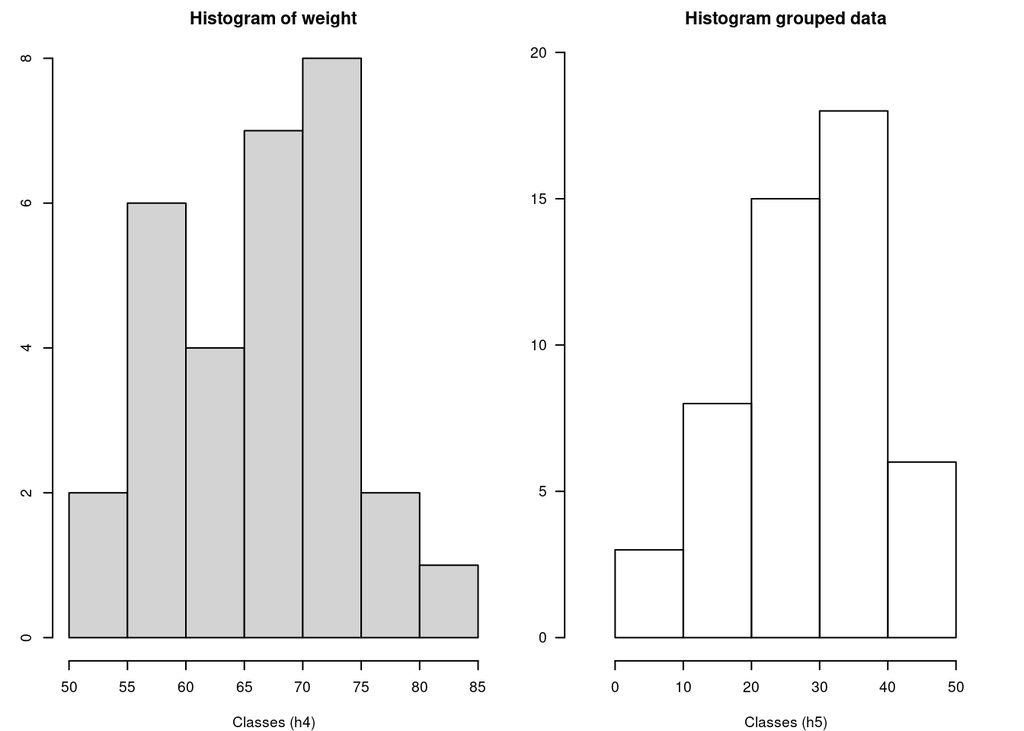

Figure 3.3: hist() function and histogram defined class

```r
oldpar<-par(mfrow=c(1,2),mar=c(4,3,2,1),cex=0.6)
h4<-hist(weight,xlab="Classes (h4)")
table.freq(h4)
# this is possible
# hh<-graph.freq(h4,plot=FALSE)
# summary(hh)
# new class
classes <- c(0, 10, 20, 30, 40, 50)
freq <- c(3, 8, 15, 18, 6)
h5 <- graph.freq(classes,counts=freq, xlab="Classes (h5)",main="Histogram grouped data")
```

```r
par(oldpar)
```

```r
print(summary(h5),row.names=FALSE)
```

```
 Lower Upper Main Frequency Percentage CF CPF
     0    10    5         3          6  3   6
    10    20   15         8         16 11  22
    20    30   25        15         30 26  52
    30    40   35        18         36 44  88
    40    50   45         6         12 50 100
```

# 4 Experimental Designs

The package **agricolae** presents special functions for the creation of the field book for experimental designs. Due to the random generation, this package is quite used in agricultural research.

For this generation, certain parameters are required, as for example the name of each treatment, the number of repetitions, and others, according to the design (Le Clerg et al., 1962; Cochran and Cox, 1992; Kuehl, 2000; Montgomery, 2002). There are other parameters of random generation, as the seed to reproduce the same random generation or the generation method ([See the reference manual of **agricolae**](http://cran.at.r-project.org/web/packages/agricolae/agricolae.pdf)).

**Important parameters in the generation of design:**

| **series:** | A constant that is used to set numerical tag blocks , eg number = 2, the labels will be : 101, 102, for the first row or block, 201, 202, for the following , in the case of completely randomized desig… |
| --- | --- |
| **design:** | Some features of the design requested agricolae be applied specifically to design.ab(factorial) or design.split (split plot) and their possible values are: “rcbd”, “crd” and “lsd”. |
| **seed:** | The seed for the random generation and its value is any real value, if the value is zero, it has no reproducible generation, in this case copy of value of the outdesign$parameters. |
| **kinds:** | the random generation method, by default “Super-Duper”. |
| **first:** | For some designs is not required random the first repetition, especially in the block design, if you want to switch to random, change to TRUE. |
| **randomization:** | TRUE or FALSE. If false, randomization is not performed |

**Output design:**

| **parameters:** | the input to generation design, include the seed to generation random, if seed=0, the program generate one value and it is possible reproduce the design. |
| --- | --- |
| **book:** | field book |
| **statistics:** | the information statistics the design for example efficiency index, number of treatments. |
| **sketch:** | distribution of treatments in the field. |
| **The enumeration of the plots** | zigzag is a function that allows you to place the numbering of the plots in the direction of serpentine: The zigzag is output generated by one design: blocks, Latin square, graeco, split plot, strip p… |
| **fieldbook:** | output zigzag, contain field book. |

## 4.1 Completely Randomized Design (CRD)

It generates completely a randomized design with equal or different repetition. “Random” uses the methods of number generation in **R**.The seed is by `set.seed(seed, kinds)`. They only require the names of the treatments and the number of their repetitions and its parameters are:

```r
str(design.crd)
```

```
function (trt, r, serie = 2, seed = 0, kinds = "Super-Duper", randomization = TRUE)
 - attr(*, "srcref")= 'srcref' int [1:8] 47 1 80 1 1 1 47 80
  ..- attr(*, "srcfile")=Classes 'srcfilecopy', 'srcfile' <environment: 0x563a676a0fa8>
```

```r
trt <- c("A", "B", "C")
repeticion <- c(4, 3, 4)
outdesign <- design.crd(trt,r=repeticion,seed=777,serie=0)
book1 <- outdesign$book
head(book1)
```

```
  plots r trt
1     1 1   C
2     2 1   A
3     3 1   B
4     4 2   A
5     5 3   A
6     6 2   C
```

Excel:write.csv(book1,“book1.csv”,row.names=FALSE)

## 4.2 Randomized Complete Block Design (RCBD)

It generates field book and sketch to Randomized Complete Block Design. “Random” uses the methods of number generation in **R**.The seed is by `set.seed(seed, kinds)`. They require the names of the treatments and the number of blocks and its parameters are:

```r
str(design.rcbd)
```

```
function (trt, r, serie = 2, seed = 0, kinds = "Super-Duper", first = TRUE,
    continue = FALSE, randomization = TRUE)
 - attr(*, "srcref")= 'srcref' int [1:8] 51 1 83 1 1 1 51 83
  ..- attr(*, "srcfile")=Classes 'srcfilecopy', 'srcfile' <environment: 0x563a6b674d50>
```

```r
trt <- c("A", "B", "C","D","E")
repeticion <- 4
outdesign <- design.rcbd(trt,r=repeticion, seed=-513, serie=2)
# book2 <- outdesign$book
book2<- zigzag(outdesign) # zigzag numeration
print(outdesign$sketch)
```

```
     [,1] [,2] [,3] [,4] [,5]
[1,] "E"  "B"  "D"  "A"  "C"
[2,] "B"  "A"  "D"  "C"  "E"
[3,] "C"  "E"  "A"  "B"  "D"
[4,] "D"  "C"  "E"  "B"  "A"
```

```r
print(matrix(book2[,1],byrow = TRUE, ncol = 5))
```

```
     [,1] [,2] [,3] [,4] [,5]
[1,]  101  102  103  104  105
[2,]  205  204  203  202  201
[3,]  301  302  303  304  305
[4,]  405  404  403  402  401
```

## 4.3 Latin Square Design

It generates Latin Square Design. “Random” uses the methods of number generation in **R**.The seed is by `set.seed(seed, kinds)`. They require the names of the treatments and its parameters are:

```r
str(design.lsd)
```

```
function (trt, serie = 2, seed = 0, kinds = "Super-Duper", first = TRUE,
    randomization = TRUE)
 - attr(*, "srcref")= 'srcref' int [1:8] 44 1 84 1 1 1 44 84
  ..- attr(*, "srcfile")=Classes 'srcfilecopy', 'srcfile' <environment: 0x563a6b906938>
```

```r
trt <- c("A", "B", "C", "D")
outdesign <- design.lsd(trt, seed=543, serie=2)
print(outdesign$sketch)
```

```
     [,1] [,2] [,3] [,4]
[1,] "B"  "C"  "A"  "D"
[2,] "D"  "A"  "C"  "B"
[3,] "C"  "D"  "B"  "A"
[4,] "A"  "B"  "D"  "C"
```

### 4.3.1 Serpentine enumeration

```r
book <- zigzag(outdesign)
print(matrix(book[,1],byrow = TRUE, ncol = 4))
```

```
     [,1] [,2] [,3] [,4]
[1,]  101  102  103  104
[2,]  204  203  202  201
[3,]  301  302  303  304
[4,]  404  403  402  401
```

## 4.4 Graeco-Latin Designs

A graeco-latin square is a $k \times k$ pattern that permits the study of $k$ treatments simultaneously with three different blocking variables, each at $k$ levels. The function is only for squares of the odd numbers and even numbers (4, 8, 10 and 12). They require the names of the treatments of each factor of study and its parameters are:

```r
str(design.graeco)
```

```
function (trt1, trt2, serie = 2, seed = 0, kinds = "Super-Duper",
    randomization = TRUE)
 - attr(*, "srcref")= 'srcref' int [1:8] 53 1 145 1 1 1 53 145
  ..- attr(*, "srcfile")=Classes 'srcfilecopy', 'srcfile' <environment: 0x563a6bf04b30>
```

```r
trt1 <- c("A", "B", "C", "D")
trt2 <- 1:4
outdesign <- design.graeco(trt1,trt2, seed=543, serie=2)
print(outdesign$sketch)
```

```
     [,1]   [,2]   [,3]   [,4]
[1,] "NA 2" "NA 4" "NA 3" "NA 1"
[2,] "NA 3" "NA 1" "NA 2" "NA 4"
[3,] "NA 1" "NA 3" "NA 4" "NA 2"
[4,] "NA 4" "NA 2" "NA 1" "NA 3"
```

### 4.4.1 Serpentine enumeration

```r
book <- zigzag(outdesign)
print(matrix(book[,1],byrow = TRUE, ncol = 4))
```

```
     [,1] [,2] [,3] [,4]
[1,]  101  102  103  104
[2,]  204  203  202  201
[3,]  301  302  303  304
[4,]  404  403  402  401
```

## 4.5 Youden Square Design

Such designs are referred to as Youden squares since they were introduced by Youden (1937) after Yates (1936) considered the special case of column equal to number treatment minus 1. “Random” uses the methods of number generation in **R**. The seed is by `set.seed(seed, kinds)`. They require the names of the treatments of each factor of study and its parameters are:

```r
str(design.youden)
```

```
function (trt, r, serie = 2, seed = 0, kinds = "Super-Duper", first = TRUE,
    randomization = TRUE)
 - attr(*, "srcref")= 'srcref' int [1:8] 50 1 96 1 1 1 50 96
  ..- attr(*, "srcfile")=Classes 'srcfilecopy', 'srcfile' <environment: 0x563a6900eaa8>
```

```r
varieties<-c("perricholi","yungay","maria bonita","tomasa")
r<-3
outdesign <-design.youden(varieties,r,serie=2,seed=23)
print(outdesign$sketch)
```

```
     [,1]           [,2]           [,3]
[1,] "maria bonita" "tomasa"       "perricholi"
[2,] "yungay"       "maria bonita" "tomasa"
[3,] "perricholi"   "yungay"       "maria bonita"
[4,] "tomasa"       "perricholi"   "yungay"
```

```r
book <- outdesign$book
print(book) # field book.
```

```
   plots row col    varieties
1    101   1   1 maria bonita
2    102   1   2       tomasa
3    103   1   3   perricholi
4    201   2   1       yungay
5    202   2   2 maria bonita
6    203   2   3       tomasa
7    301   3   1   perricholi
8    302   3   2       yungay
9    303   3   3 maria bonita
10   401   4   1       tomasa
11   402   4   2   perricholi
12   403   4   3       yungay
```

```r
print(matrix(as.numeric(book[,1]),byrow = TRUE, ncol = r))
```

```
     [,1] [,2] [,3]
[1,]  101  102  103
[2,]  201  202  203
[3,]  301  302  303
[4,]  401  402  403
```

### 4.5.1 Serpentine enumeration

```r
book <- zigzag(outdesign)
print(matrix(as.numeric(book[,1]),byrow = TRUE, ncol = r))
```

```
     [,1] [,2] [,3]
[1,]  101  102  103
[2,]  203  202  201
[3,]  301  302  303
[4,]  403  402  401
```

## 4.6 Balanced Incomplete Block Designs (BIBD)

Creates Randomized Balanced Incomplete Block Design. “Random” uses the methods of number generation in **R**. The seed is by `set.seed(seed, kinds)`. They require the names of the treatments and the size of the block and its parameters are:

```r
str(design.bib)
```

```
function (trt, k, r = NULL, serie = 2, seed = 0, kinds = "Super-Duper",
    maxRep = 20, randomization = TRUE)
 - attr(*, "srcref")= 'srcref' int [1:8] 64 1 145 1 1 1 64 145
  ..- attr(*, "srcfile")=Classes 'srcfilecopy', 'srcfile' <environment: 0x563a679a1518>
```

```r
trt <- c("A", "B", "C", "D", "E" )
k <- 4
outdesign <- design.bib(trt,k, seed=543, serie=2)
```

```
Parameters BIB
==============
Lambda     : 3
treatmeans : 5
Block size : 4
Blocks     : 5
Replication: 4

Efficiency factor 0.9375

<<< Book >>>
```

```r
book5 <- outdesign$book
outdesign$statistics
```

```
       lambda treatmeans blockSize blocks r Efficiency
values      3          5         4      5 4     0.9375
```

```r
outdesign$parameters
```

```
$design
[1] "bib"

$trt
[1] "A" "B" "C" "D" "E"

$k
[1] 4

$serie
[1] 2

$seed
[1] 543

$kinds
[1] "Super-Duper"
```

According to the produced information, they are five blocks of size 4, being the matrix:

```r
outdesign$sketch
```

```
     [,1] [,2] [,3] [,4]
[1,] "B"  "C"  "E"  "A"
[2,] "C"  "D"  "B"  "A"
[3,] "A"  "D"  "E"  "B"
[4,] "E"  "C"  "D"  "B"
[5,] "D"  "C"  "E"  "A"
```

### 4.6.1 Serpentine enumeration

```r
book <- zigzag(outdesign)
matrix(book[,1],byrow = TRUE, ncol = 4)
```

```
     [,1] [,2] [,3] [,4]
[1,]  101  102  103  104
[2,]  204  203  202  201
[3,]  301  302  303  304
[4,]  404  403  402  401
[5,]  501  502  503  504
```

## 4.7 Cyclic Designs

They require the names of the treatments, the size of the block and the number of repetitions. This design is used for 6 to 30 treatments. The repetitions are a multiple of the size of the block; if they are six treatments and the size is 3, then the repetitions can be 6, 9, 12, etc. and its parameters are:

```r
str(design.cyclic)
```

```
function (trt, k, r, serie = 2, rowcol = FALSE, seed = 0, kinds = "Super-Duper",
    randomization = TRUE)
 - attr(*, "srcref")= 'srcref' int [1:8] 51 1 198 1 1 1 51 198
  ..- attr(*, "srcfile")=Classes 'srcfilecopy', 'srcfile' <environment: 0x563a69a345e8>
```

```r
trt <- c("A", "B", "C", "D", "E", "F" )
outdesign <- design.cyclic(trt,k=3, r=6, seed=543, serie=2)
```

```
cyclic design
Generator block basic:
1 2 4
1 3 2

Parameters
===================
treatmeans : 6
Block size : 3
Replication: 6
```

```r
book6 <- outdesign$book
outdesign$sketch[[1]]
```

```
     [,1] [,2] [,3]
[1,] "F"  "D"  "C"
[2,] "C"  "B"  "E"
[3,] "D"  "E"  "A"
[4,] "B"  "E"  "F"
[5,] "A"  "F"  "C"
[6,] "B"  "A"  "D"
```

```r
outdesign$sketch[[2]]
```

```
     [,1] [,2] [,3]
[1,] "A"  "F"  "E"
[2,] "A"  "C"  "B"
[3,] "A"  "F"  "B"
[4,] "C"  "D"  "E"
[5,] "E"  "D"  "F"
[6,] "D"  "C"  "B"
```

### 4.7.1 Serpentine enumeration

```r
book <- zigzag(outdesign)
array(book$plots,c(3,6,2))->X
t(X[,,1])
```

```
     [,1] [,2] [,3]
[1,]  101  102  103
[2,]  106  105  104
[3,]  107  108  109
[4,]  112  111  110
[5,]  113  114  115
[6,]  118  117  116
```

```r
t(X[,,2])
```

```
     [,1] [,2] [,3]
[1,]  201  202  203
[2,]  206  205  204
[3,]  207  208  209
[4,]  212  211  210
[5,]  213  214  215
[6,]  218  217  216
```

## 4.8 Lattice Designs

**SIMPLE** and **TRIPLE** lattice designs. It randomizes treatments in $k \times k$ lattice. They require a number of treatments of a perfect square; for example 9, 16, 25, 36, 49, etc. and its parameters are:

```r
str(design.lattice)
```

```
function (trt, r = 3, serie = 2, seed = 0, kinds = "Super-Duper",
    randomization = TRUE)
 - attr(*, "srcref")= 'srcref' int [1:8] 41 1 117 1 1 1 41 117
  ..- attr(*, "srcfile")=Classes 'srcfilecopy', 'srcfile' <environment: 0x563a6b9f0630>
```

They can generate a simple lattice (2 rep.) or a triple lattice (3 rep.) generating a triple lattice design for 9 treatments $3 \times 3$

```r
trt<-letters[1:9]
outdesign <-design.lattice(trt, r = 3, serie = 2, seed = 33,
    kinds =  "Super-Duper")
```

```
Lattice design,  triple   3 x 3

Efficiency factor
(E ) 0.7272727

<<< Book >>>
```

```r
book7 <- outdesign$book
outdesign$parameters
```

```
$design
[1] "lattice"

$type
[1] "triple"

$trt
[1] "a" "b" "c" "d" "e" "f" "g" "h" "i"

$r
[1] 3

$serie
[1] 2

$seed
[1] 33

$kinds
[1] "Super-Duper"
```

```r
outdesign$sketch
```

```
$rep1
     [,1] [,2] [,3]
[1,] "g"  "c"  "a"
[2,] "f"  "b"  "h"
[3,] "i"  "e"  "d"

$rep2
     [,1] [,2] [,3]
[1,] "g"  "f"  "i"
[2,] "a"  "h"  "d"
[3,] "c"  "b"  "e"

$rep3
     [,1] [,2] [,3]
[1,] "g"  "h"  "e"
[2,] "c"  "f"  "d"
[3,] "a"  "b"  "i"
```

```r
head(book7)
```

```
  plots r block trt
1   101 1     1   g
2   102 1     1   c
3   103 1     1   a
4   104 1     2   f
5   105 1     2   b
6   106 1     2   h
```

### 4.8.1 Serpentine enumeration

```r
book <- zigzag(outdesign)
array(book$plots,c(3,3,3)) -> X
t(X[,,1])
```

```
     [,1] [,2] [,3]
[1,]  101  102  103
[2,]  106  105  104
[3,]  107  108  109
```

```r
t(X[,,2])
```

```
     [,1] [,2] [,3]
[1,]  201  202  203
[2,]  206  205  204
[3,]  207  208  209
```

```r
t(X[,,3])
```

```
     [,1] [,2] [,3]
[1,]  301  302  303
[2,]  306  305  304
[3,]  307  308  309
```

## 4.9 Alpha Designs

Generates an alpha designs starting from the alpha design fixing under the series formulated by Patterson and Williams. These designs are generated by the alpha arrangements. They are similar to the lattice designs, but the tables are rectangular $s$ by $k$ (with $s$ blocks and $k<s$ columns. The number of treatments should be equal to $s \times k$ and all the experimental units $r \times s \times k$ ($r$ replications) and its parameters are:

```r
str(design.alpha)
```

```
function (trt, k, r, serie = 2, seed = 0, kinds = "Super-Duper",
    randomization = TRUE)
 - attr(*, "srcref")= 'srcref' int [1:8] 71 1 213 1 1 1 71 213
  ..- attr(*, "srcfile")=Classes 'srcfilecopy', 'srcfile' <environment: 0x563a67a717d8>
```

```r
trt <- letters[1:15]
outdesign <- design.alpha(trt,k=3,r=2,seed=543)
```

```
Alpha Design (0,1) - Serie  I

Parameters Alpha Design
=======================
Treatmeans : 15
Block size : 3
Blocks     : 5
Replication: 2

Efficiency factor
(E ) 0.6363636

<<< Book >>>
```

```r
book8 <- outdesign$book
outdesign$statistics
```

```
       treatments blocks Efficiency
values         15      5  0.6363636
```

```r
outdesign$sketch
```

```
$rep1
     [,1] [,2] [,3]
[1,] "i"  "g"  "m"
[2,] "f"  "o"  "h"
[3,] "n"  "j"  "b"
[4,] "a"  "c"  "k"
[5,] "e"  "l"  "d"

$rep2
     [,1] [,2] [,3]
[1,] "g"  "f"  "k"
[2,] "e"  "j"  "a"
[3,] "m"  "c"  "l"
[4,] "n"  "d"  "o"
[5,] "i"  "h"  "b"
```

```r
# codification of the plots
A<-array(book8[,1], c(3,5,2))
t(A[,,1])
```

```
     [,1] [,2] [,3]
[1,]  101  102  103
[2,]  104  105  106
[3,]  107  108  109
[4,]  110  111  112
[5,]  113  114  115
```

```r
t(A[,,2])
```

```
     [,1] [,2] [,3]
[1,]  201  202  203
[2,]  204  205  206
[3,]  207  208  209
[4,]  210  211  212
[5,]  213  214  215
```

### 4.9.1 Serpentine enumeration

```r
book <- zigzag(outdesign)
A<-array(book[,1], c(3,5,2))
t(A[,,1])
```

```
     [,1] [,2] [,3]
[1,]  101  102  103
[2,]  106  105  104
[3,]  107  108  109
[4,]  112  111  110
[5,]  113  114  115
```

```r
t(A[,,2])
```

```
     [,1] [,2] [,3]
[1,]  201  202  203
[2,]  206  205  204
[3,]  207  208  209
[4,]  212  211  210
[5,]  213  214  215
```

## 4.10 Augmented Block Designs

These are designs for two types of treatments: the control treatments (common) and the increased treatments. The common treatments are applied in complete randomized blocks, and the increased treatments, at random. Each treatment should be applied in any block once only. It is understood that the common treatments are of a greater interest; the standard error of the difference is much smaller than when between two increased ones in different blocks. The function `design.dau()` achieves this purpose and its parameters are:

```r
str(design.dau)
```

```
function (trt1, trt2, r, serie = 2, seed = 0, kinds = "Super-Duper",
    name = "trt", randomization = TRUE)
 - attr(*, "srcref")= 'srcref' int [1:8] 57 1 96 1 1 1 57 96
  ..- attr(*, "srcfile")=Classes 'srcfilecopy', 'srcfile' <environment: 0x563a6b9a9148>
```

```r
rm(list=ls())
trt1 <- c("A", "B", "C", "D")
trt2 <- c("t","u","v","w","x","y","z")
outdesign <- design.dau(trt1, trt2, r=5, seed=543, serie=2)
book9 <- outdesign$book
with(book9,by(trt, block,as.character))
```

```
block: 1
[1] "C" "B" "v" "D" "t" "A"
------------------------------------------------------
block: 2
[1] "D" "u" "A" "B" "x" "C"
------------------------------------------------------
block: 3
[1] "B" "y" "C" "A" "D"
------------------------------------------------------
block: 4
[1] "A" "B" "C" "D" "w"
------------------------------------------------------
block: 5
[1] "z" "A" "C" "D" "B"
```

### 4.10.1 Serpentine enumeration

```r
book <- zigzag(outdesign)
with(book,by(plots, block, as.character))
```

```
block: 1
[1] "101" "102" "103" "104" "105" "106"
------------------------------------------------------
block: 2
[1] "206" "205" "204" "203" "202" "201"
------------------------------------------------------
block: 3
[1] "301" "302" "303" "304" "305"
------------------------------------------------------
block: 4
[1] "405" "404" "403" "402" "401"
------------------------------------------------------
block: 5
[1] "501" "502" "503" "504" "505"
```

```r
head(book)
```

```
  plots block trt
1   101     1   C
2   102     1   B
3   103     1   v
4   104     1   D
5   105     1   t
6   106     1   A
```

For augmented ompletely randomized design, use the function design.crd().

## 4.11 Split Plot Designs

These designs have two factors, one is applied in plots and is defined as **trt1** in a randomized complete block design; and a second factor as **trt2** , which is applied in the subplots of each plot applied at random. The function design.split() permits to find the experimental plan for this design and its parameters are:

```r
str(design.split)
```

```
function (trt1, trt2, r = NULL, design = c("rcbd", "crd", "lsd"),
    serie = 2, seed = 0, kinds = "Super-Duper", first = TRUE, randomization = TRUE)
 - attr(*, "srcref")= 'srcref' int [1:8] 46 1 102 1 1 1 46 102
  ..- attr(*, "srcfile")=Classes 'srcfilecopy', 'srcfile' <environment: 0x563a6a1ecb58>
```

### 4.11.1 Aplication

```r
trt1<-c("A","B","C","D")
trt2<-c("a","b","c")
outdesign <-design.split(trt1,trt2,r=3,serie=2,seed=543)
book10 <- outdesign$book
head(book10)
```

```
  plots splots block trt1 trt2
1   101      1     1    D    b
2   101      2     1    D    a
3   101      3     1    D    c
4   102      1     1    B    a
5   102      2     1    B    b
6   102      3     1    B    c
```

```r
p<-book10$trt1[seq(1,36,3)]
q<-NULL
for(i in 1:12)
q <- c(q,paste(book10$trt2[3*(i-1)+1],book10$trt2[3*(i-1)+2], book10$trt2[3*(i-1)+3]))
```

### 4.11.2 In plots:

```r
print(t(matrix(p,c(4,3))))
```

```
     [,1] [,2] [,3] [,4]
[1,] "D"  "B"  "A"  "C"
[2,] "B"  "C"  "A"  "D"
[3,] "D"  "B"  "A"  "C"
```

### 4.11.3 In sub plots (split plot)

```r
print(t(matrix(q,c(4,3))))
```

```
     [,1]    [,2]    [,3]    [,4]
[1,] "b a c" "a b c" "c a b" "c b a"
[2,] "b c a" "a b c" "b c a" "a c b"
[3,] "c a b" "b c a" "c a b" "a c b"
```

### 4.11.4 Serpentine enumeration

```r
book <- zigzag(outdesign)
head(book,5)
```

```
  plots splots block trt1 trt2
1   101      1     1    D    b
2   101      2     1    D    a
3   101      3     1    D    c
4   102      1     1    B    a
5   102      2     1    B    b
```

## 4.12 Strip-Plot Designs

These designs are used when there are two types of treatments (factors) and are applied separately in large plots, called bands, in a vertical and horizontal direction of the block, obtaining the divided blocks. Each block constitutes a repetition and its parameters are:

```r
str(design.strip)
```

```
function (trt1, trt2, r, serie = 2, seed = 0, kinds = "Super-Duper",
    randomization = TRUE)
 - attr(*, "srcref")= 'srcref' int [1:8] 45 1 84 1 1 1 45 84
  ..- attr(*, "srcfile")=Classes 'srcfilecopy', 'srcfile' <environment: 0x563a6a0f7ac0>
```

### 4.12.1 Aplication

```r
trt1<-c("A","B","C","D")
trt2<-c("a","b","c")
outdesign <-design.strip(trt1,trt2,r=3,serie=2,seed=543)
book11 <- outdesign$book
head(book11)
```

```
  plots block trt1 trt2
1   101     1    D    b
2   102     1    D    a
3   103     1    D    c
4   104     1    B    b
5   105     1    B    a
6   106     1    B    c
```

```r
t3<-paste(book11$trt1, book11$trt2)
B1<-t(matrix(t3[1:12],c(4,3)))
B2<-t(matrix(t3[13:24],c(3,4)))
B3<-t(matrix(t3[25:36],c(3,4)))
print(B1)
```

```
     [,1]  [,2]  [,3]  [,4]
[1,] "D b" "D a" "D c" "B b"
[2,] "B a" "B c" "A b" "A a"
[3,] "A c" "C b" "C a" "C c"
```

```r
print(B2)
```

```
     [,1]  [,2]  [,3]
[1,] "C b" "C a" "C c"
[2,] "B b" "B a" "B c"
[3,] "A b" "A a" "A c"
[4,] "D b" "D a" "D c"
```

```r
print(B3)
```

```
     [,1]  [,2]  [,3]
[1,] "A c" "A b" "A a"
[2,] "B c" "B b" "B a"
[3,] "D c" "D b" "D a"
[4,] "C c" "C b" "C a"
```

### 4.12.2 Serpentine enumeration

```r
book <- zigzag(outdesign)
head(book)
```

```
  plots block trt1 trt2
1   101     1    D    b
2   102     1    D    a
3   103     1    D    c
4   106     1    B    b
5   105     1    B    a
6   104     1    B    c
```

```r
array(book$plots,c(3,4,3))->X
t(X[,,1])
```

```
     [,1] [,2] [,3]
[1,]  101  102  103
[2,]  106  105  104
[3,]  107  108  109
[4,]  112  111  110
```

```r
t(X[,,2])
```

```
     [,1] [,2] [,3]
[1,]  201  202  203
[2,]  206  205  204
[3,]  207  208  209
[4,]  212  211  210
```

```r
t(X[,,3])
```

```
     [,1] [,2] [,3]
[1,]  301  302  303
[2,]  306  305  304
[3,]  307  308  309
[4,]  312  311  310
```

## 4.13 Factorial

The full factorial of n factors applied to an experimental design (CRD, RCBD and LSD) is common and this procedure in **agricolae** applies the factorial to one of these three designs and its parameters are:

```r
str(design.ab)
```

```
function (trt, r = NULL, serie = 2, design = c("rcbd", "crd", "lsd"),
    seed = 0, kinds = "Super-Duper", first = TRUE, randomization = TRUE)
 - attr(*, "srcref")= 'srcref' int [1:8] 51 1 107 1 1 1 51 107
  ..- attr(*, "srcfile")=Classes 'srcfilecopy', 'srcfile' <environment: 0x563a68f3c980>
```

To generate the factorial, you need to create a vector of levels of each factor, the method automatically generates up to 25 factors and $r$ repetitions.

```r
trt <- c (4,2,3) # three factors with  4,2 and 3 levels.
```

to crd and rcbd designs, it is necessary to value $r$ as the number of repetitions, this can be a vector if unequal to equal or constant repetition (recommended).

```r
trt<-c(3,2) # factorial 3x2
outdesign <-design.ab(trt, r=3, serie=2)
book12 <- outdesign$book
head(book12) # print of the field book
```

```
  plots block A B
1   101     1 2 2
2   102     1 2 1
3   103     1 3 2
4   104     1 1 2
5   105     1 1 1
6   106     1 3 1
```

### 4.13.1 Serpentine enumeration

```r
book <- zigzag(outdesign)
head(book)
```

```
  plots block A B
1   101     1 2 2
2   102     1 2 1
3   103     1 3 2
4   104     1 1 2
5   105     1 1 1
6   106     1 3 1
```

factorial $2 \times 2 \times 2$ with 5 replications in completely randomized design.

```r
trt<-c(2,2,2)
crd<-design.ab(trt, r=5, serie=2,design="crd")
names(crd)
```

```
[1] "parameters" "book"
```

```r
crd$parameters
```

```
$design
[1] "factorial"

$trt
[1] "1 1 1" "1 1 2" "1 2 1" "1 2 2" "2 1 1" "2 1 2" "2 2 1" "2 2 2"

$r
[1] 5 5 5 5 5 5 5 5

$serie
[1] 2

$seed
[1] 1923434691

$kinds
[1] "Super-Duper"

[[7]]
[1] TRUE

$applied
[1] "crd"
```

```r
head(crd$book)
```

```
  plots r A B C
1   101 1 2 2 2
2   102 2 2 2 2
3   103 1 2 1 1
4   104 1 1 2 1
5   105 1 1 1 1
6   106 2 1 2 1
```

# 5 Multiple Comparisons

For the analyses, the following functions of **agricolae** are used: `LSD.test`, `HSD.test`, `duncan.test`, `scheffe.test`, `waller.test`, `SNK.test`, `REGW.test` (Hsu, 1996; Steel et al., 1997) and `durbin.test`, `kruskal`, `friedman`, `waerden.test` and `Median.test` (Conover, 1999).

For every statistical analysis, the data should be organized in columns. For the demonstration, the **agricolae** database will be used.

The `sweetpotato` data correspond to a completely random experiment in field with plots of 50 sweet potato plants, subjected to the virus effect and to a control without virus (See the reference manual of the package).

```r
data(sweetpotato)
model<-aov(yield~virus, data=sweetpotato)
cv.model(model)
```

```
[1] 17.1666
```

```r
with(sweetpotato,mean(yield))
```

```
[1] 27.625
```

**Model parameters: Degrees of freedom and variance of the error:**

```r
df<-df.residual(model)
MSerror<-deviance(model)/df
```

### 5.0.1 The Least Significant Difference (LSD)

It includes the multiple comparison through the method of the minimum significant difference (Least Significant Difference), (Steel et al., 1997).

```r
# comparison <- LSD.test(yield,virus,df,MSerror)
LSD.test(model, "virus",console=TRUE)
```

```
Study: model ~ "virus"

LSD t Test for yield

Mean Square Error:  22.48917

virus,  means and individual ( 95 %) CI

      yield      std r       LCL      UCL  Min  Max
cc 24.40000 3.609709 3 18.086268 30.71373 21.7 28.5
fc 12.86667 2.159475 3  6.552935 19.18040 10.6 14.9
ff 36.33333 7.333030 3 30.019601 42.64707 28.0 41.8
oo 36.90000 4.300000 3 30.586268 43.21373 32.1 40.4

Alpha: 0.05 ; DF Error: 8
Critical Value of t: 2.306004

least Significant Difference: 8.928965

Treatments with the same letter are not significantly different.

      yield groups
oo 36.90000      a
ff 36.33333      a
cc 24.40000      b
fc 12.86667      c
```

In the function `LSD.test`, the multiple comparison was carried out. In order to obtain the probabilities of the comparisons, it should be indicated that groups are not required; thus:

```r
# comparison <- LSD.test(yield, virus,df, MSerror, group=FALSE)
outLSD <-LSD.test(model, "virus", group=FALSE,console=TRUE)
```

```
Study: model ~ "virus"

LSD t Test for yield

Mean Square Error:  22.48917

virus,  means and individual ( 95 %) CI

      yield      std r       LCL      UCL  Min  Max
cc 24.40000 3.609709 3 18.086268 30.71373 21.7 28.5
fc 12.86667 2.159475 3  6.552935 19.18040 10.6 14.9
ff 36.33333 7.333030 3 30.019601 42.64707 28.0 41.8
oo 36.90000 4.300000 3 30.586268 43.21373 32.1 40.4

Alpha: 0.05 ; DF Error: 8
Critical Value of t: 2.306004

Comparison between treatments means

         difference pvalue signif.        LCL        UCL
cc - fc  11.5333333 0.0176       *   2.604368  20.462299
cc - ff -11.9333333 0.0151       * -20.862299  -3.004368
cc - oo -12.5000000 0.0121       * -21.428965  -3.571035
fc - ff -23.4666667 0.0003     *** -32.395632 -14.537701
fc - oo -24.0333333 0.0003     *** -32.962299 -15.104368
ff - oo  -0.5666667 0.8873          -9.495632   8.362299
```

Signif. codes:

```r
options(digits=2)
print(outLSD)
```

```
$statistics
  MSerror Df Mean CV t.value LSD
       22  8   28 17     2.3 8.9

$parameters
        test p.ajusted name.t ntr alpha
  Fisher-LSD      none  virus   4  0.05

$means
   yield std r  LCL UCL Min Max Q25 Q50 Q75
cc    24 3.6 3 18.1  31  22  28  22  23  26
fc    13 2.2 3  6.6  19  11  15  12  13  14
ff    36 7.3 3 30.0  43  28  42  34  39  40
oo    37 4.3 3 30.6  43  32  40  35  38  39

$comparison
        difference pvalue signif.   LCL   UCL
cc - fc      11.53 0.0176       *   2.6  20.5
cc - ff     -11.93 0.0151       * -20.9  -3.0
cc - oo     -12.50 0.0121       * -21.4  -3.6
fc - ff     -23.47 0.0003     *** -32.4 -14.5
fc - oo     -24.03 0.0003     *** -33.0 -15.1
ff - oo      -0.57 0.8873          -9.5   8.4

$groups
NULL

attr(,"class")
[1] "group"
```

### 5.0.2 holm, hommel, hochberg, bonferroni, BH, BY, fdr

With the function `LSD.test` we can make adjustments to the probabilities found, as for example the adjustment by Bonferroni, holm and other options see Adjust P-values for Multiple Comparisons, function ‘p.adjust(stats)’ (R Core Team, 2020).

```r
LSD.test(model, "virus", group=FALSE, p.adj= "bon",console=TRUE)
```

```
Study: model ~ "virus"

LSD t Test for yield
P value adjustment method: bonferroni

Mean Square Error:  22

virus,  means and individual ( 95 %) CI

   yield std r  LCL UCL Min Max
cc    24 3.6 3 18.1  31  22  28
fc    13 2.2 3  6.6  19  11  15
ff    36 7.3 3 30.0  43  28  42
oo    37 4.3 3 30.6  43  32  40

Alpha: 0.05 ; DF Error: 8
Critical Value of t: 3.5

Comparison between treatments means

        difference pvalue signif.   LCL    UCL
cc - fc      11.53 0.1058          -1.9  25.00
cc - ff     -11.93 0.0904       . -25.4   1.54
cc - oo     -12.50 0.0725       . -26.0   0.97
fc - ff     -23.47 0.0018      ** -36.9 -10.00
fc - oo     -24.03 0.0015      ** -37.5 -10.56
ff - oo      -0.57 1.0000         -14.0  12.90
```

```r
out<-LSD.test(model, "virus", group=TRUE, p.adj= "holm")
print(out$group)
```

```
   yield groups
oo    37      a
ff    36      a
cc    24      b
fc    13      c
```

```r
out<-LSD.test(model, "virus", group=FALSE, p.adj= "holm")
print(out$comparison)
```

```
        difference pvalue signif.
cc - fc      11.53 0.0484       *
cc - ff     -11.93 0.0484       *
cc - oo     -12.50 0.0484       *
fc - ff     -23.47 0.0015      **
fc - oo     -24.03 0.0015      **
ff - oo      -0.57 0.8873
```

Other comparison tests can be applied, such as *duncan, Student-Newman-Keuls, tukey and waller-duncan*

For **Duncan**, use the function `duncan.test`; for **Student-Newman-Keuls**, the function `SNK.test`; for **Tukey**, the function `HSD.test`; for **Scheffe**, the function `scheffe.test` and for **Waller-Duncan**, the function `waller.test`. The arguments are the same. `Waller` also requires the value of F-calculated of the ANOVA treatments. If the model is used as a parameter, this is no longer necessary.

### 5.0.3 Duncan’s New Multiple-Range Test

It corresponds to the Duncan’s Test (Steel et al., 1997).

```r
duncan.test(model, "virus",console=TRUE)
```

```
Study: model ~ "virus"

Duncan's new multiple range test
for yield

Mean Square Error:  22

virus,  means

   yield std r Min Max
cc    24 3.6 3  22  28
fc    13 2.2 3  11  15
ff    36 7.3 3  28  42
oo    37 4.3 3  32  40

Alpha: 0.05 ; DF Error: 8

Critical Range
  2   3   4
8.9 9.3 9.5

Means with the same letter are not significantly different.

   yield groups
oo    37      a
ff    36      a
cc    24      b
fc    13      c
```

### 5.0.4 Student-Newman-Keuls

Student, Newman and Keuls helped to improve the Newman-Keuls test of 1939, which was known as the Keuls method (Steel et al., 1997).

```r
# SNK.test(model, "virus", alpha=0.05,console=TRUE)
SNK.test(model, "virus", group=FALSE,console=TRUE)
```

```
Study: model ~ "virus"

Student Newman Keuls Test
for yield

Mean Square Error:  22

virus,  means

   yield std r Min Max
cc    24 3.6 3  22  28
fc    13 2.2 3  11  15
ff    36 7.3 3  28  42
oo    37 4.3 3  32  40

Comparison between treatments means

        difference pvalue signif.   LCL   UCL
cc - fc      11.53 0.0176       *   2.6  20.5
cc - ff     -11.93 0.0151       * -20.9  -3.0
cc - oo     -12.50 0.0291       * -23.6  -1.4
fc - ff     -23.47 0.0008     *** -34.5 -12.4
fc - oo     -24.03 0.0012      ** -36.4 -11.6
ff - oo      -0.57 0.8873          -9.5   8.4
```

### 5.0.5 Ryan, Einot and Gabriel and Welsch

Multiple range tests for all pairwise comparisons, to obtain a confident inequalities multiple range tests (Hsu, 1996).

```r
# REGW.test(model, "virus", alpha=0.05,console=TRUE)
REGW.test(model, "virus", group=FALSE,console=TRUE)
```

```
Study: model ~ "virus"

Ryan, Einot and Gabriel and Welsch multiple range test
for yield

Mean Square Error:  22

virus,  means

   yield std r Min Max
cc    24 3.6 3  22  28
fc    13 2.2 3  11  15
ff    36 7.3 3  28  42
oo    37 4.3 3  32  40

Comparison between treatments means

        difference pvalue signif.    LCL    UCL
cc - fc      11.53 0.0350       *   0.91  22.16
cc - ff     -11.93 0.0360       * -23.00  -0.87
cc - oo     -12.50 0.0482       * -24.90  -0.10
fc - ff     -23.47 0.0006     *** -34.09 -12.84
fc - oo     -24.03 0.0007     *** -35.10 -12.97
ff - oo      -0.57 0.9873         -11.19  10.06
```

### 5.0.6 Tukey’s W Procedure (HSD)

This studentized range test, created by Tukey in 1953, is known as the Tukey’s HSD (Honestly Significant Differences) (Steel et al., 1997).

```r
outHSD<- HSD.test(model, "virus",console=TRUE)
```

```
Study: model ~ "virus"

HSD Test for yield

Mean Square Error:  22

virus,  means

   yield std r Min Max
cc    24 3.6 3  22  28
fc    13 2.2 3  11  15
ff    36 7.3 3  28  42
oo    37 4.3 3  32  40

Alpha: 0.05 ; DF Error: 8
Critical Value of Studentized Range: 4.5

Minimun Significant Difference: 12

Treatments with the same letter are not significantly different.

   yield groups
oo    37      a
ff    36     ab
cc    24     bc
fc    13      c
```

```r
outHSD
```

```
$statistics
  MSerror Df Mean CV MSD
       22  8   28 17  12

$parameters
   test name.t ntr StudentizedRange alpha
  Tukey  virus   4              4.5  0.05

$means
   yield std r Min Max Q25 Q50 Q75
cc    24 3.6 3  22  28  22  23  26
fc    13 2.2 3  11  15  12  13  14
ff    36 7.3 3  28  42  34  39  40
oo    37 4.3 3  32  40  35  38  39

$comparison
NULL

$groups
   yield groups
oo    37      a
ff    36     ab
cc    24     bc
fc    13      c

attr(,"class")
[1] "group"
```

### 5.0.7 Tukey (HSD) for different repetition

Include the argument **unbalanced = TRUE** in the function. Valid for group = TRUE/FALSE

```r
A<-sweetpotato[-c(4,5,7),]
modelUnbalanced <- aov(yield ~ virus, data=A)
outUn <-HSD.test(modelUnbalanced, "virus",group=FALSE, unbalanced = TRUE)
print(outUn$comparison)
```

```
        difference pvalue signif. LCL  UCL
cc - fc       11.3  0.252          -8 30.6
cc - ff       -9.2  0.386         -28 10.1
cc - oo      -12.5  0.196         -32  6.8
fc - ff      -20.5  0.040       * -40 -1.2
fc - oo      -23.8  0.022       * -43 -4.5
ff - oo       -3.3  0.917         -23 16.0
```

```r
outUn <-HSD.test(modelUnbalanced, "virus",group=TRUE, unbalanced = TRUE)
print(outUn$groups)
```

```
   yield groups
oo    37      a
ff    34      a
cc    24     ab
fc    13      b
```

If this argument is not included, the probabilities of significance will not be consistent with the choice of groups.

Illustrative example of this inconsistency:

```r
outUn <-HSD.test(modelUnbalanced, "virus",group=FALSE)
print(outUn$comparison[,1:2])
```

```
        difference pvalue
cc - fc       11.3  0.317
cc - ff       -9.2  0.297
cc - oo      -12.5  0.096
fc - ff      -20.5  0.071
fc - oo      -23.8  0.033
ff - oo       -3.3  0.885
```

```r
outUn <-HSD.test(modelUnbalanced, "virus",group=TRUE)
print(outUn$groups)
```

```
   yield groups
oo    37      a
ff    34     ab
cc    24     ab
fc    13      b
```

### 5.0.8 Waller-Duncan’s Bayesian K-Ratio T-Test

Duncan continued the multiple comparison procedures, introducing the criterion of minimizing both experimental errors; for this, he used the Bayes’ theorem, obtaining one new test called Waller-Duncan (Waller and Duncan, 1969; Steel et al., 1997).

```r
# variance analysis:
anova(model)
```

```
Analysis of Variance Table

Response: yield
          Df Sum Sq Mean Sq F value  Pr(>F)
virus      3   1170     390    17.3 0.00073 ***
Residuals  8    180      22
---
Signif. codes:  0 '***' 0.001 '**' 0.01 '*' 0.05 '.' 0.1 ' ' 1
```

```r
with(sweetpotato,waller.test(yield,virus,df,MSerror,Fc= 17.345, group=FALSE,console=TRUE))
```

```
Study: yield ~ virus

Waller-Duncan K-ratio t Test for yield

This test minimizes the Bayes risk under additive loss and certain other assumptions
                         ......
K ratio                   100.0
Error Degrees of Freedom    8.0
Error Mean Square          22.5
F value                    17.3
Critical Value of Waller    2.2

virus,  means

   yield std r Min Max
cc    24 3.6 3  22  28
fc    13 2.2 3  11  15
ff    36 7.3 3  28  42
oo    37 4.3 3  32  40

Comparison between treatments means

        Difference significant
cc - fc      11.53        TRUE
cc - ff     -11.93        TRUE
cc - oo     -12.50        TRUE
fc - ff     -23.47        TRUE
fc - oo     -24.03        TRUE
ff - oo      -0.57       FALSE
```

In another case with only invoking the model object:

```r
outWaller <- waller.test(model, "virus", group=FALSE,console=FALSE)
```

The found object *outWaller* has information to make other procedures.

```r
names(outWaller)
```

```
[1] "statistics" "parameters" "means"      "comparison" "groups"
```

```r
print(outWaller$comparison)
```

```
        Difference significant
cc - fc      11.53        TRUE
cc - ff     -11.93        TRUE
cc - oo     -12.50        TRUE
fc - ff     -23.47        TRUE
fc - oo     -24.03        TRUE
ff - oo      -0.57       FALSE
```

It is indicated that the virus effect “ff” is not significant to the control “oo”.

```r
outWaller$statistics
```

```
  Mean Df CV MSerror F.Value Waller CriticalDifference
    28  8 17      22      17    2.2                8.7
```

## 5.1 Scheffe’s Test

This method, created by Scheffe in 1959, is very general for all the possible contrasts and their confidence intervals. The confidence intervals for the averages are very broad, resulting in a very conservative test for the comparison between treatment averages (Steel et al., 1997).

```r
# analysis of variance:
scheffe.test(model,"virus", group=TRUE,console=TRUE,
main="Yield of sweetpotato\nDealt with different virus")
```

```
Study: Yield of sweetpotato
Dealt with different virus

Scheffe Test for yield

Mean Square Error  : 22

virus,  means

   yield std r Min Max
cc    24 3.6 3  22  28
fc    13 2.2 3  11  15
ff    36 7.3 3  28  42
oo    37 4.3 3  32  40

Alpha: 0.05 ; DF Error: 8
Critical Value of F: 4.1

Minimum Significant Difference: 14

Means with the same letter are not significantly different.

   yield groups
oo    37      a
ff    36      a
cc    24     ab
fc    13      b
```

The minimum significant value is very high. If you require the approximate probabilities of comparison, you can use the option *group=FALSE*.

```r
outScheffe <- scheffe.test(model,"virus", group=FALSE, console=TRUE)
```

```
Study: model ~ "virus"

Scheffe Test for yield

Mean Square Error  : 22

virus,  means

   yield std r Min Max
cc    24 3.6 3  22  28
fc    13 2.2 3  11  15
ff    36 7.3 3  28  42
oo    37 4.3 3  32  40

Alpha: 0.05 ; DF Error: 8
Critical Value of F: 4.1

Comparison between treatments means

        Difference pvalue sig LCL   UCL
cc - fc      11.53 0.0978   .  -2  25.1
cc - ff     -11.93 0.0855   . -25   1.6
cc - oo     -12.50 0.0706   . -26   1.0
fc - ff     -23.47 0.0023  ** -37  -9.9
fc - oo     -24.03 0.0020  ** -38 -10.5
ff - oo      -0.57 0.9991     -14  13.0
```

## 5.2 Multiple comparison in factorial treatments

In a factorial combined effects of the treatments. Comparetive tests: `LSD, HSD, Waller-Duncan, Duncan, Scheff\'e, SNK` can be applied.

```r
# modelABC <-aov (y ~ A * B * C, data)
# compare <-LSD.test (modelABC, c ("A", "B", "C"),console=TRUE)
```

**The comparison is the combination of A:B:C.**

Data RCBD design with a factorial clone x nitrogen. The response variable yield.

```r
yield <-scan (text =
 "6 7 9 13 16 20 8 8 9
  7 8 8 12 17 18 10 9 12
  9 9 9 14 18 21 11 12 11
  8 10 10 15 16 22 9 9 9 "
 )
block <-gl (4, 9)
clone <-rep (gl (3, 3, labels = c ("c1", "c2", "c3")), 4)
nitrogen <-rep (gl (3, 1, labels = c ("n1", "n2", "n3")), 12)
A <-data.frame (block, clone, nitrogen, yield)
head (A)
```

```
  block clone nitrogen yield
1     1    c1       n1     6
2     1    c1       n2     7
3     1    c1       n3     9
4     1    c2       n1    13
5     1    c2       n2    16
6     1    c2       n3    20
```

```r
outAOV <-aov (yield ~ block + clone * nitrogen, data = A)
```

```r
anova (outAOV)
```

```
Analysis of Variance Table

Response: yield
               Df Sum Sq Mean Sq F value  Pr(>F)
block           3     21     6.9    5.82 0.00387 **
clone           2    498   248.9  209.57 6.4e-16 ***
nitrogen        2     54    27.0   22.76 2.9e-06 ***
clone:nitrogen  4     43    10.8    9.11 0.00013 ***
Residuals      24     29     1.2
---
Signif. codes:  0 '***' 0.001 '**' 0.01 '*' 0.05 '.' 0.1 ' ' 1
```

```r
outFactorial <-LSD.test (outAOV, c("clone", "nitrogen"),
main = "Yield ~ block + nitrogen + clone + clone:nitrogen",console=TRUE)
```

```
Study: Yield ~ block + nitrogen + clone + clone:nitrogen

LSD t Test for yield

Mean Square Error:  1.2

clone:nitrogen,  means and individual ( 95 %) CI

      yield  std r  LCL  UCL Min Max
c1:n1   7.5 1.29 4  6.4  8.6   6   9
c1:n2   8.5 1.29 4  7.4  9.6   7  10
c1:n3   9.0 0.82 4  7.9 10.1   8  10
c2:n1  13.5 1.29 4 12.4 14.6  12  15
c2:n2  16.8 0.96 4 15.6 17.9  16  18
c2:n3  20.2 1.71 4 19.1 21.4  18  22
c3:n1   9.5 1.29 4  8.4 10.6   8  11
c3:n2   9.5 1.73 4  8.4 10.6   8  12
c3:n3  10.2 1.50 4  9.1 11.4   9  12

Alpha: 0.05 ; DF Error: 24
Critical Value of t: 2.1

least Significant Difference: 1.6

Treatments with the same letter are not significantly different.

      yield groups
c2:n3  20.2      a
c2:n2  16.8      b
c2:n1  13.5      c
c3:n3  10.2      d
c3:n1   9.5     de
c3:n2   9.5     de
c1:n3   9.0    def
c1:n2   8.5     ef
c1:n1   7.5      f
```

```r
oldpar<-par(mar=c(3,3,2,0))
pic1<-bar.err(outFactorial$means,variation="range",ylim=c(5,25), bar=FALSE,col=0,las=1)
points(pic1$index,pic1$means,pch=18,cex=1.5,col="blue")
axis(1,pic1$index,labels=FALSE)
title(main="average and range\nclon:nitrogen")
par(oldpar)
```

[output not shown]

## 5.3 Analysis of Balanced Incomplete Blocks

```r
# Example linear estimation and design of experiments. (Joshi)
# Institute of Social Sciences Agra, India
# 6 varieties of wheat in 10 blocks of 3 plots each.
block<-gl(10,3)
variety<-c(1,2,3,1,2,4,1,3,5,1,4,6,1,5,6,2,3,6,2,4,5,2,5,6,3,4,5,3, 4,6)
Y<-c(69,54,50,77,65,38,72,45,54,63,60,39,70,65,54,65,68,67,57,60,62,
59,65,63,75,62,61,59,55,56)
head(cbind(block,variety,Y))
```

```
     block variety  Y
[1,]     1       1 69
[2,]     1       2 54
[3,]     1       3 50
[4,]     2       1 77
[5,]     2       2 65
[6,]     2       4 38
```

```r
BIB.test(block, variety, Y,console=TRUE)
```

```
ANALYSIS BIB:  Y
Class level information

Block:  1 2 3 4 5 6 7 8 9 10
Trt  :  1 2 3 4 5 6

Number of observations:  30

Analysis of Variance Table

Response: Y
            Df Sum Sq Mean Sq F value Pr(>F)
block.unadj  9    467    51.9    0.90  0.547
trt.adj      5   1156   231.3    4.02  0.016 *
Residuals   15    863    57.5
---
Signif. codes:  0 '***' 0.001 '**' 0.01 '*' 0.05 '.' 0.1 ' ' 1

coefficient of variation: 13 %
Y Means: 60

variety,  statistics

   Y mean.adj  SE r  std Min Max
1 70       75 3.7 5  5.1  63  77
2 60       59 3.7 5  4.9  54  65
3 59       59 3.7 5 12.4  45  75
4 55       55 3.7 5  9.8  38  62
5 61       60 3.7 5  4.5  54  65
6 56       54 3.7 5 10.8  39  67

LSD test
Std.diff   : 5.4
Alpha      : 0.05
LSD        : 11
Parameters BIB
Lambda     : 2
treatmeans : 6
Block size : 3
Blocks     : 10
```

[output cut: 18 more lines]

```
3 - 5      -1.50 0.7836
3 - 6       4.17 0.4492
4 - 5      -5.08 0.3582
4 - 6       0.58 0.9148
5 - 6       5.67 0.3074

Treatments with the same letter are not significantly different.

   Y groups
1 75      a
5 60      b
2 59      b
3 59      b
4 55      b
6 54      b
```

**function (block, trt, Y, test = c(“lsd”, “tukey”, “duncan”, “waller”, “snk”), alpha = 0.05, group = TRUE)** LSD, Tukey Duncan, Waller-Duncan and SNK, can be used. The probabilities of the comparison can also be obtained. It should only be indicated: group=FALSE, thus:

```r
out <-BIB.test(block, trt=variety, Y, test="tukey", group=FALSE, console=TRUE)
```

```
ANALYSIS BIB:  Y
Class level information

Block:  1 2 3 4 5 6 7 8 9 10
Trt  :  1 2 3 4 5 6

Number of observations:  30

Analysis of Variance Table

Response: Y
            Df Sum Sq Mean Sq F value Pr(>F)
block.unadj  9    467    51.9    0.90  0.547
trt.adj      5   1156   231.3    4.02  0.016 *
Residuals   15    863    57.5
---
Signif. codes:  0 '***' 0.001 '**' 0.01 '*' 0.05 '.' 0.1 ' ' 1

coefficient of variation: 13 %
Y Means: 60

variety,  statistics

   Y mean.adj  SE r  std Min Max
1 70       75 3.7 5  5.1  63  77
2 60       59 3.7 5  4.9  54  65
3 59       59 3.7 5 12.4  45  75
4 55       55 3.7 5  9.8  38  62
5 61       60 3.7 5  4.5  54  65
6 56       54 3.7 5 10.8  39  67

Tukey
Alpha      : 0.05
Std.err    : 3.8
HSD        : 17
Parameters BIB
Lambda     : 2
treatmeans : 6
Block size : 3
Blocks     : 10
```

[output cut: 8 more lines]

```
1 - 2      16.42  0.070    .
1 - 3      16.58  0.067    .
1 - 4      20.17  0.019    *
1 - 5      15.08  0.110
1 - 6      20.75  0.015    *
2 - 3       0.17  1.000
2 - 4       3.75  0.979
2 - 5      -1.33  1.000
2 - 6       4.33  0.962
3 - 4       3.58  0.983
3 - 5      -1.50  1.000
3 - 6       4.17  0.967
4 - 5      -5.08  0.927
4 - 6       0.58  1.000
5 - 6       5.67  0.891
```

```r
names(out)
```

```
[1] "parameters" "statistics" "comparison" "means"      "groups"
```

```r
rm(block,variety)
```

**bar.group:** out$groups

**bar.err:** out$means

## 5.4 Partially Balanced Incomplete Blocks

The function `PBIB.test` (Joshi, 1987), can be used for the lattice and alpha designs.

Consider the following case: Construct the alpha design with 30 treatments, 2 repetitions, and a block size equal to 3.

```r
# alpha design
Genotype<-paste("geno",1:30,sep="")
r<-2
k<-3
plan<-design.alpha(Genotype,k,r,seed=5)
```

```
Alpha Design (0,1) - Serie  I

Parameters Alpha Design
=======================
Treatmeans : 30
Block size : 3
Blocks     : 10
Replication: 2

Efficiency factor
(E ) 0.62

<<< Book >>>
```

The generated plan is plan$book. Suppose that the corresponding observation to each experimental unit is:

```r
yield <-c(5,2,7,6,4,9,7,6,7,9,6,2,1,1,3,2,4,6,7,9,8,7,6,4,3,2,2,1,1,
          2,1,1,2,4,5,6,7,8,6,5,4,3,1,1,2,5,4,2,7,6,6,5,6,4,5,7,6,5,5,4)
```

The data table is constructed for the analysis. In theory, it is presumed that a design is applied and the experiment is carried out; subsequently, the study variables are observed from each experimental unit.

```r
data<-data.frame(plan$book,yield)
# The analysis:
modelPBIB <- with(data,PBIB.test(block, Genotype, replication, yield, k=3, group=TRUE, console=TRUE))
```

```
ANALYSIS PBIB:  yield

Class level information
block : 20
Genotype : 30

Number of observations:  60

Estimation Method:  Residual (restricted) maximum likelihood

Parameter Estimates
                  Variance
block:replication  3.8e+00
replication        6.1e-09
Residual           1.7e+00

                      Fit Statistics
AIC                              214
BIC                              260
-2 Res Log Likelihood            -74

Analysis of Variance Table

Response: yield
          Df Sum Sq Mean Sq F value Pr(>F)
Genotype  29   69.2    2.39     1.4   0.28
Residuals 11   18.7    1.70

Coefficient of variation: 29 %
yield Means: 4.5

Parameters PBIB
                   .
Genotype          30
block size         3
block/replication 10
replication        2

Efficiency factor 0.62

```

[output cut: 22 more lines]

```
geno23       4.0   abcd
geno15       3.9   abcd
geno2        3.8    bcd
geno4        3.8    bcd
geno3        3.7    bcd
geno25       3.6    bcd
geno12       3.6    bcd
geno6        3.6    bcd
geno21       3.4    bcd
geno24       3.0    bcd
geno13       2.8     cd
geno20       2.7     cd
geno7        2.3      d

<<< to see the objects: means, comparison and groups. >>>
```

**The adjusted averages can be extracted from the modelPBIB.**

head(modelPBIB$means)

**The comparisons:**

head(modelPBIB$comparison)

The data on the adjusted averages and their variation can be illustrated with the functions plot.group and bar.err. Since the created object is very similar to the objects generated by the multiple comparisons.

Analysis of balanced lattice 3x3, 9 treatments, 4 repetitions.

Create the data in a text file: latice3x3.txt and read with R:

```r
trt<-c(1,8,5,5,2,9,2,7,3,6,4,9,4,6,9,8,7,6,1,5,8,3,2,7,3,7,2,1,3,4,6,4,9,5,8,1)
yield<-c(48.76,10.83,12.54,11.07,22,47.43,27.67,30,13.78,37,42.37,39,14.46,30.69,42.01,
22,42.8,28.28,50,24,24,15.42,30,23.8,19.68,31,23,41,12.9,49.95,25,45.57,30,20,18,43.81)
sqr<-rep(gl(4,3),3)
block<-rep(1:12,3)
modelLattice<-PBIB.test(block,trt,sqr,yield,k=3,console=TRUE, method="VC")
```

```
ANALYSIS PBIB:  yield

Class level information
block : 12
trt : 9

Number of observations:  36

Estimation Method:  Variances component model

    Fit Statistics
AIC            265
BIC            298

Analysis of Variance Table

Response: yield
          Df Sum Sq Mean Sq F value  Pr(>F)
sqr        3    133      44    0.69 0.57361
trt.unadj  8   3749     469    7.24 0.00042 ***
block/sqr  8    368      46    0.71 0.67917
Residual  16   1036      65
---
Signif. codes:  0 '***' 0.001 '**' 0.01 '*' 0.05 '.' 0.1 ' ' 1

Coefficient of variation: 28 %
yield Means: 29

Parameters PBIB
           .
trt        9
block size 3
block/sqr  3
sqr        4

Efficiency factor 0.75

Comparison test lsd

Treatments with the same letter are not significantly different.

  yield.adj groups
1        44      a
9        39     ab
4        39     ab
7        32     bc
6        31     bc
2        26     cd
8        18      d
5        17      d
3        15      d

<<< to see the objects: means, comparison and groups. >>>
```

**The adjusted averages can be extracted from the modelLattice.**

print(modelLattice$means)

**The comparisons:**

head(modelLattice$comparison)

## 5.5 Augmented Blocks

The function `DAU.test` can be used for the analysis of the augmented block design. The data should be organized in a table, containing the blocks, treatments, and the response.

```r
block<-c(rep("I",7),rep("II",6),rep("III",7))
trt<-c("A","B","C","D","g","k","l","A","B","C","D","e","i","A","B", "C",
"D","f","h","j")
yield<-c(83,77,78,78,70,75,74,79,81,81,91,79,78,92,79,87,81,89,96, 82)
head(data.frame(block, trt, yield))
```

```
  block trt yield
1     I   A    83
2     I   B    77
3     I   C    78
4     I   D    78
5     I   g    70
6     I   k    75
```

**The treatments are in each block:**

```r
by(trt,block,as.character)
```

```
block: I
[1] "A" "B" "C" "D" "g" "k" "l"
------------------------------------------------------
block: II
[1] "A" "B" "C" "D" "e" "i"
------------------------------------------------------
block: III
[1] "A" "B" "C" "D" "f" "h" "j"
```

**With their respective responses:**

```r
by(yield,block,as.character)
```

```
block: I
[1] "83" "77" "78" "78" "70" "75" "74"
------------------------------------------------------
block: II
[1] "79" "81" "81" "91" "79" "78"
------------------------------------------------------
block: III
[1] "92" "79" "87" "81" "89" "96" "82"
```

**Analysis:**

```r
modelDAU<- DAU.test(block,trt,yield,method="lsd",console=TRUE)
```

```
ANALYSIS DAU:  yield
Class level information

Block:  I II III
Trt  :  A B C D e f g h i j k l

Number of observations:  20

ANOVA, Treatment Adjusted
Analysis of Variance Table

Response: yield
                          Df Sum Sq Mean Sq F value Pr(>F)
block.unadj                2    360   180.0
trt.adj                   11    285    25.9    0.96   0.55
Control                    3     53    17.6    0.65   0.61
Control + control.VS.aug.  8    232    29.0    1.08   0.48
Residuals                  6    162    27.0

ANOVA, Block Adjusted
Analysis of Variance Table

Response: yield
                     Df Sum Sq Mean Sq F value Pr(>F)
trt.unadj            11    576    52.3
block.adj             2     70    34.8    1.29   0.34
Control               3     53    17.6    0.65   0.61
Augmented             7    506    72.3    2.68   0.13
Control vs augmented  1     17    16.9    0.63   0.46
Residuals             6    162    27.0

coefficient of variation: 6.4 %
yield Means: 82

Critical Differences (Between)
                                              Std Error Diff.
Two Control Treatments                                    4.2
Two Augmented Treatments (Same Block)                     7.3
Two Augmented Treatments(Different Blocks)                8.2
A Augmented Treatment and A Control Treatment             6.4


Treatments with the same letter are not significantly different.

  yield groups
h    94      a
f    86     ab
A    85     ab
D    83     ab
C    82     ab
j    80     ab
B    79     ab
e    78     ab
k    78     ab
i    77     ab
l    77     ab
g    73      b

Comparison between treatments means

<<< to see the objects: comparison and means  >>>
```

```r
options(digits = 2)
modelDAU$means
```

```
  yield std r Min Max Q25 Q50 Q75 mean.adj  SE block
A    85 6.7 3  79  92  81  83  88       85 3.0
B    79 2.0 3  77  81  78  79  80       79 3.0
C    82 4.6 3  78  87  80  81  84       82 3.0
D    83 6.8 3  78  91  80  81  86       83 3.0
e    79  NA 1  79  79  79  79  79       78 5.2    II
f    89  NA 1  89  89  89  89  89       86 5.2   III
g    70  NA 1  70  70  70  70  70       73 5.2     I
h    96  NA 1  96  96  96  96  96       94 5.2   III
i    78  NA 1  78  78  78  78  78       77 5.2    II
j    82  NA 1  82  82  82  82  82       80 5.2   III
k    75  NA 1  75  75  75  75  75       78 5.2     I
l    74  NA 1  74  74  74  74  74       77 5.2     I
```

```r
modelDAU<- DAU.test(block,trt,yield,method="lsd",group=FALSE,console=FALSE)
head(modelDAU$comparison,8)
```

```
      Difference pvalue sig.
A - B        5.7   0.23
A - C        2.7   0.55
A - D        1.3   0.76
A - e        6.4   0.35
A - f       -1.8   0.78
A - g       11.4   0.12
A - h       -8.8   0.21
A - i        7.4   0.29
```

# 6 Non-parametric Comparisons

The functions for non-parametric multiple comparisons included in **agricolae** are: `kruskal`, `waerden.test`, `friedman` and `durbin.test` (Conover, 1999).

The post hoc nonparametrics tests (kruskal, friedman, durbin and waerden) are using the criterium Fisher’s least significant difference (LSD).

The function `kruskal` is used for N samples (N>2), populations or data coming from a completely random experiment (populations = treatments).

The function `waerden.test`, similar to kruskal-wallis, uses a normal score instead of ranges as kruskal does.

The function `friedman` is used for organoleptic evaluations of different products, made by judges (every judge evaluates all the products). It can also be used for the analysis of treatments of the randomized complete block design, where the response cannot be treated through the analysis of variance.

The function `durbin.test` for the analysis of balanced incomplete block designs is very used for sampling tests, where the judges only evaluate a part of the treatments.

The function `Median.test` for the analysis the distribution is approximate with chi-squared ditribution with degree free number of groups minus one. In each comparison a table of $2 \times 2$ (pair of groups) and the criterion of greater or lesser value than the median of both are formed, the chi-square test is applied for the calculation of the probability of error that both are independent. This value is compared to the alpha level for group formation.

Montgomery book data (Montgomery, 2002). Included in the **agricolae** package

```r
data(corn)
str(corn)
```

```
'data.frame':   34 obs. of  3 variables:
 $ method     : int  1 1 1 1 1 1 1 1 1 2 ...
 $ observation: int  83 91 94 89 89 96 91 92 90 91 ...
 $ rx         : num  11 23 28.5 17 17 31.5 23 26 19.5 23 ...
```

**For the examples, the** agricolae** package data will be used**

## 6.1 Kruskal-Wallis

It makes the multiple comparison with Kruskal-Wallis. The parameters by default are alpha = 0.05.

```r
str(kruskal)
```

```
function (y, trt, alpha = 0.05, p.adj = c("none", "holm", "hommel",
    "hochberg", "bonferroni", "BH", "BY", "fdr"), group = TRUE,
    main = NULL, console = FALSE)
 - attr(*, "srcref")= 'srcref' int [1:8] 42 3 202 3 3 3 42 202
  ..- attr(*, "srcfile")=Classes 'srcfilecopy', 'srcfile' <environment: 0x563a6912e460>
```

### 6.1.1 Analysis

```r
outKruskal<-with(corn,kruskal(observation,method,group=TRUE, main="corn", console=TRUE))
```

```
Study: corn
Kruskal-Wallis test's
Ties or no Ties

Critical Value: 26
Degrees of freedom: 3
Pvalue Chisq  : 1.1e-05

method,  means of the ranks

  observation  r
1        21.8  9
2        15.3 10
3        29.6  7
4         4.8  8

Post Hoc Analysis

t-Student: 2
Alpha    : 0.05
Groups according to probability of treatment differences and alpha level.

Treatments with the same letter are not significantly different.

  observation groups
3        29.6      a
1        21.8      b
2        15.3      c
4         4.8      d
```

The object output has the same structure of the comparisons see the functions plot.group(agricolae), bar.err(agricolae) and bar.group(agricolae).

### 6.1.2 Kruskal-Wallis: adjust P-values

To see `p.adjust.methods()`

```r
out<-with(corn,kruskal(observation,method,group=TRUE, main="corn", p.adj="holm"))
print(out$group)
```

```
  observation groups
3        29.6      a
1        21.8      b
2        15.3      c
4         4.8      d
```

```r
out<-with(corn,kruskal(observation,method,group=FALSE, main="corn", p.adj="holm"))
print(out$comparison)
```

```
      Difference pvalue Signif.
1 - 2        6.5 0.0079      **
1 - 3       -7.7 0.0079      **
1 - 4       17.0 0.0000     ***
2 - 3      -14.3 0.0000     ***
2 - 4       10.5 0.0003     ***
3 - 4       24.8 0.0000     ***
```

## 6.2 Friedman

The data consist of b mutually independent k-variate random variables called b blocks. The random variable is in a block and is associated with treatment. It makes the multiple comparison of the Friedman test with or without ties. A first result is obtained by `friedman.test` of R.

```r
str(friedman)
```

```
function (judge, trt, evaluation, alpha = 0.05, group = TRUE, main = NULL,
    console = FALSE)
 - attr(*, "srcref")= 'srcref' int [1:8] 46 3 192 3 3 3 46 192
  ..- attr(*, "srcfile")=Classes 'srcfilecopy', 'srcfile' <environment: 0x563a68f21ea8>
```

### 6.2.1 Analysis

```r
data(grass)
out<-with(grass,friedman(judge,trt, evaluation,alpha=0.05, group=FALSE,
main="Data of the book of Conover",console=TRUE))
```

```
Study: Data of the book of Conover

trt,  Sum of the ranks

   evaluation  r
t1         38 12
t2         24 12
t3         24 12
t4         34 12

Friedman's Test
===============
Adjusted for ties
Critical Value: 8.1
P.Value Chisq: 0.044
F Value: 3.2
P.Value F: 0.036

Post Hoc Analysis

Comparison between treatments
Sum of the ranks

        difference pvalue signif.   LCL   UCL
t1 - t2       14.5  0.015       *   3.0 25.98
t1 - t3       13.5  0.023       *   2.0 24.98
t1 - t4        4.0  0.483          -7.5 15.48
t2 - t3       -1.0  0.860         -12.5 10.48
t2 - t4      -10.5  0.072       . -22.0  0.98
t3 - t4       -9.5  0.102         -21.0  1.98
```

## 6.3 Waerden

A nonparametric test for several independent samples. Example applied with the sweet potato data in the **agricolae** basis.

```r
str(waerden.test)
```

```
function (y, trt, alpha = 0.05, group = TRUE, main = NULL, console = FALSE)
 - attr(*, "srcref")= 'srcref' int [1:8] 46 3 166 3 3 3 46 166
  ..- attr(*, "srcfile")=Classes 'srcfilecopy', 'srcfile' <environment: 0x563a6b0709e0>
```

### 6.3.1 Analysis

```r
data(sweetpotato)
outWaerden<-with(sweetpotato,waerden.test(yield,virus,alpha=0.01,group=TRUE,console=TRUE))
```

```
Study: yield ~ virus
Van der Waerden (Normal Scores) test's

Value : 8.4
Pvalue: 0.038
Degrees of Freedom:  3

virus,  means of the normal score

   yield  std r
cc -0.23 0.30 3
fc -1.06 0.35 3
ff  0.69 0.76 3
oo  0.60 0.37 3

Post Hoc Analysis

Alpha: 0.01 ; DF Error: 8

Minimum Significant Difference: 1.3

Treatments with the same letter are not significantly different.

Means of the normal score

   score groups
ff  0.69      a
oo  0.60      a
cc -0.23     ab
fc -1.06      b
```

The comparison probabilities are obtained with the parameter group = **FALSE**.

```r
names(outWaerden)
```

```
[1] "statistics" "parameters" "means"      "comparison" "groups"
```

**To see outWaerden$comparison**

```r
out<-with(sweetpotato,waerden.test(yield,virus,group=FALSE,console=TRUE))
```

```
Study: yield ~ virus
Van der Waerden (Normal Scores) test's

Value : 8.4
Pvalue: 0.038
Degrees of Freedom:  3

virus,  means of the normal score

   yield  std r
cc -0.23 0.30 3
fc -1.06 0.35 3
ff  0.69 0.76 3
oo  0.60 0.37 3

Post Hoc Analysis

Comparison between treatments
mean of the normal score

        difference pvalue signif.    LCL    UCL
cc - fc      0.827 0.0690       . -0.082  1.736
cc - ff     -0.921 0.0476       * -1.830 -0.013
cc - oo     -0.837 0.0664       . -1.746  0.072
fc - ff     -1.749 0.0022      ** -2.658 -0.840
fc - oo     -1.665 0.0029      ** -2.574 -0.756
ff - oo      0.084 0.8363         -0.825  0.993
```